# Miniproyecto 3

## Modelación y Simulación

Javier Anleu Alegría - 17149

Andrea Argüello - 17801

### Teorema del Límite Central

El **Teorema del Límite Central** establece que, para una muestra $X_1, X_2, ..., X_n$ con media $\overline{X}$ de una distribución con media $\mu$ y varianza $\sigma^2$, el límite cuando $n\to\infty$ de la forma estandarizada de $\overline{X}$ tiende asintóticamente a la distribución normal $\Phi(z)$.

Matemáticamente,

$$\lim_{n\to\infty} P\Big(\frac{\overline{X}-\mu}{\sigma / \sqrt{n}}\Big) = \Phi(z)$$

De esta manera, cuando $n$ es lo suficientemente grande, $\overline{X}$ tiene una distribución aproximadamente normal con media $\mu_{\overline{X}} = \mu$ y varianza $\sigma_{\overline{X}}^2 = \sigma^2 / n$ (Devore y Berk, 2018).

Este miniproyecto busca demostrar este teorema por medio de la simulación de números aleatorios de la distribución uniforme continua $\mathscr{U}(0,1)$, generando $N = \{50, 100\}$ muestras de tamaños $n = \{20, 40, 60, 80, 100\}$, de tal manera que hubiera 50 muestras de tamaño 20, 100 muestras de tamaño 20, 50 muestras de tamaño 40, etc. Adicionalmente, se comparó el resultado obtenido cuando se generaron 100 muestras de tamaño 100 versus $10^5$ muestras de tamaño $10^5$.

*Literatura citada:*

Devore, J. L. y Berk, K. N. (2018). *Modern Mathematical Statistics with Applications*. New York: Springer.

### Librerías

```python
import random
from matplotlib import pyplot as plt
import numpy as np
import math
from scipy.stats import norm
```

### Simulación

#### Configuración del *seed*

```python
random.seed(2573)
```

### Límites teóricos de $\mu$ y $\sigma²$

Recordar que, para una distribución continua uniforme, $$ \mu = \frac{a+b}{2}, \quad \sigma^2 = \frac{(b-a)^2}{12} $$

Si $a = 0$ y $b = 1$, entonces $$ \mu = \frac{0+1}{2}=\frac{1}{2}, \quad \sigma^2 = \frac{1-0}{12} = \frac{1}{12} $$

```python
mu = 0.5
sigma2 = 1/12
```

#### Función para calcular promedios

```python
array_avg = lambda X: sum(X)/len(X)
```

#### Función para calcular promedios centrados

```python
def centr_avg (x, n):
    return (x-mu)/((sigma2**0.5)/(n**0.5))
```

#### Generación de Números Aleatorios

Se generan una matriz de 3 dimensiones donde se almacenan los promedios centrados de los números generados de la siguiente manera:

- *Primera dimensión:* Número $N$ de repeticiones (50 o 100)
- *Segunda dimensión:* Tamaño $n$ de la muestra (20, 40, 60, 80, 100)
- *Tercera dimensión:* $N$-ésimo promedio de la muestra de tamaño $n$

```python
n = [20, 40, 60, 80, 100]
N = [50, 100]
```

```python
averages = []

for i in N:
    n_averages = []
    for j in n:
        N_averages = []
        for k in range(i):
            x = []
            for l in range(j):
                x.append(random.random())
            N_averages.append(centr_avg(array_avg(x),j))
        n_averages.append(N_averages)
    averages.append(n_averages)
```

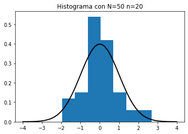

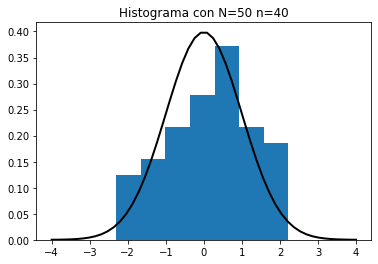

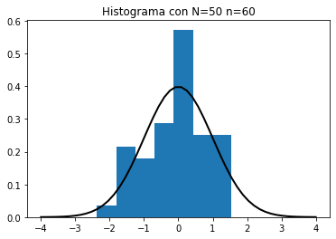

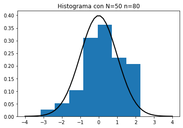

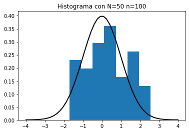

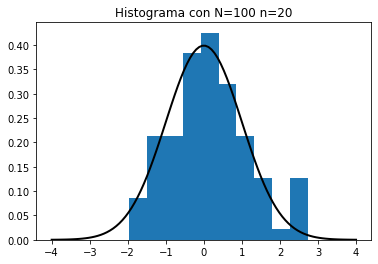

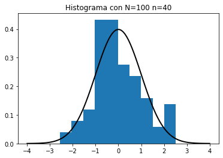

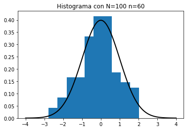

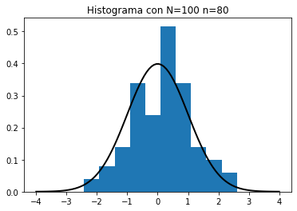

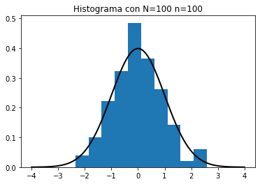

```python
for i in range(len(averages)):
    for j in range(len(averages[i])):
        plt.hist(averages[i][j], bins=math.floor((len(averages[i][j])**.5)), density=True)
        xmin, xmax = plt.xlim()
        x = np.linspace(-4, 4, N[i])
        p = norm.pdf(x, 0, 1)
        plt.plot(x, p, 'k', linewidth=2)
        plt.title('Histograma con N=%d n=%d' % (N[i],n[j]))
        plt.show()
```

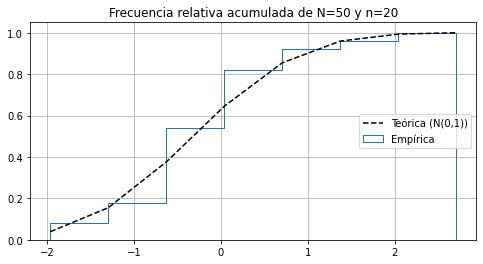

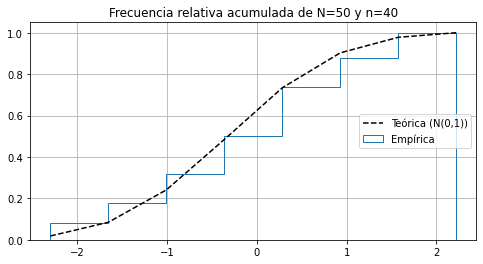

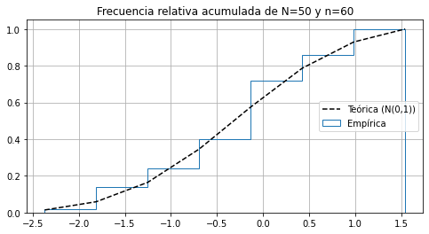

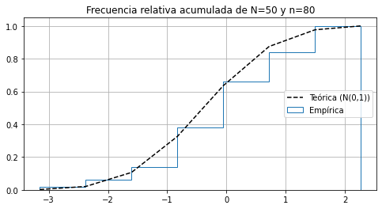

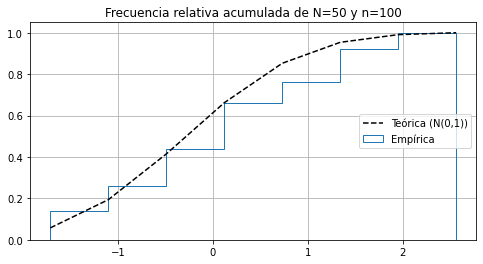

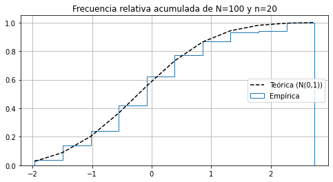

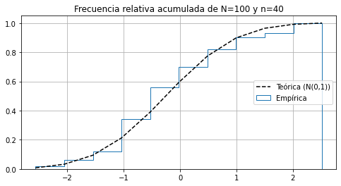

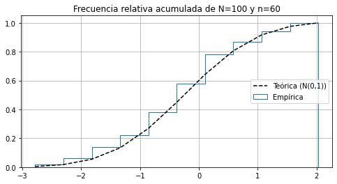

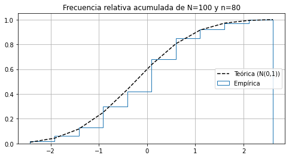

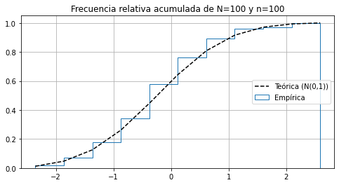

```python
for i in range(len(averages)):
    for j in range(len(averages[i])):
        fig, ax = plt.subplots(figsize=(8, 4))

        # plot the cumulative histogram
        n_ij, bins, patches = ax.hist(averages[i][j], math.floor((len(averages[i][j])**.5)), density=True, histtype='step',
                                   cumulative=True, label='Empírica')

        # Add a line showing the expected distribution.
        y = ((1 / (np.sqrt(2 * np.pi) * 1)) *
             np.exp(-0.5 * (1 / 1 * (bins - 0))**2))
        y = y.cumsum()
        y /= y[-1]

        ax.plot(bins, y, 'k--', linewidth=1.5, label='Teórica (N(0,1))')


        # tidy up the figure
        ax.grid(True)
        ax.legend(loc='right')
        ax.set_title('Frecuencia relativa acumulada de N=%d y n=%d' % (N[i],n[j]))

        plt.show()
```

Se puede observar que al aumentar tanto $N$ como $n$, el comportamiento de la densidad del histograma y la frecuencia relativa acumulada se van asemejando más a la distribución normal $N(0,1)$.

### Comparación con muestras más grandes

Se hizo una comparación de los resultados obtenidos cuando $N = 100$ y $n = 100$ versus los obtenidos cuando $N=10^5$ y $n = 10^5$.

```python
n = [100, 100000]
N = [100, 100000]
```

```python
averages = []

for i in N:
    n_averages = []
    for j in n:
        N_averages = []
        for k in range(i):
            x = []
            for l in range(j):
                x.append(random.random())
            N_averages.append(centr_avg(array_avg(x),j))
        n_averages.append(N_averages)
    averages.append(n_averages)
```

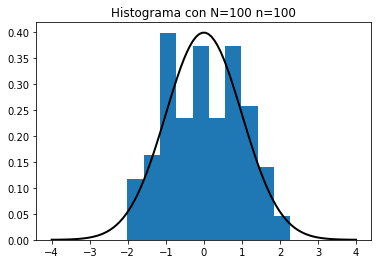

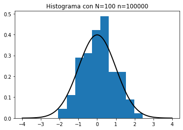

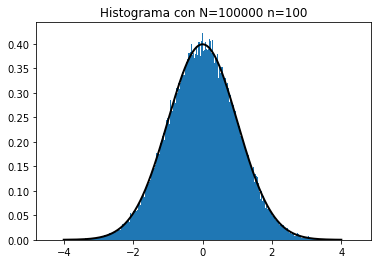

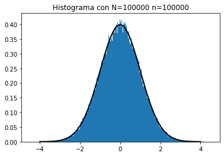

```python
for i in range(len(averages)):
    for j in range(len(averages[i])):
        plt.hist(averages[i][j], bins=math.floor((len(averages[i][j])**.5)), density=True)
        xmin, xmax = plt.xlim()
        x = np.linspace(-4, 4, N[i])
        p = norm.pdf(x, 0, 1)
        plt.plot(x, p, 'k', linewidth=2)
        plt.title('Histograma con N=%d n=%d' % (N[i],n[j]))
        plt.show()
```

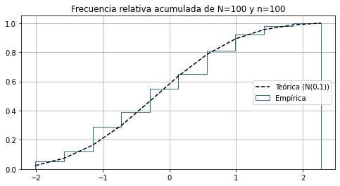

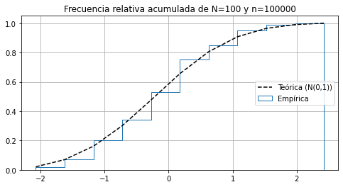

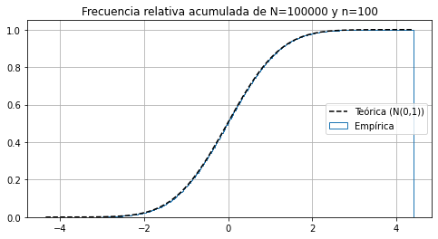

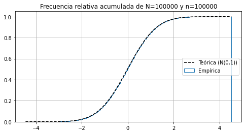

```python
for i in range(len(averages)):
    for j in range(len(averages[i])):
        fig, ax = plt.subplots(figsize=(8, 4))

        # plot the cumulative histogram
        n_ij, bins, patches = ax.hist(averages[i][j], math.floor((len(averages[i][j])**.5)), density=True, histtype='step',
                                   cumulative=True, label='Empírica')

        # Add a line showing the expected distribution.
        y = ((1 / (np.sqrt(2 * np.pi) * 1)) *
             np.exp(-0.5 * (1 / 1 * (bins - 0))**2))
        y = y.cumsum()
        y /= y[-1]

        ax.plot(bins, y, 'k--', linewidth=1.5, label='Teórica (N(0,1))')


        # tidy up the figure
        ax.grid(True)
        ax.legend(loc='right')
        ax.set_title('Frecuencia relativa acumulada de N=%d y n=%d' % (N[i],n[j]))

        plt.show()
```

### Conclusión

Se comprobó el teorema del límite central por medio de la generación de números aleatorios de una distribución $\mathscr{U}(0,1)$ en $N = \{50, 100, 10^5\}$ muestras de tamaño $n = \{20, 40, 60, 80, 100, 10^5\}$, respectivamente, tal que $\overline{X}_n \xrightarrow[n \to \infty]{} \Phi{z}$